# RNAseq Intro Analysis

Libby Li

2026-03-17

```r
counts = na.omit(read.table(file = "gene_counts.tsv", sep = '\t', header = TRUE))
```

Experiment: Macrophages were either trained with (phosphate-buffered saline, a control) or interferon-gamma (IFNy, a cytokine) for 24 hours. IFNy-treated cells represent an initial infection. The overarching goal of this analysis is to explore innate immune memory and see how cells that have encountered an infection in the past respond to future infections differently than cells that haven’t.

Next, ALL macrophages were stimulated with LPS (Lipopolysaccharide, a molecule that triggers immune system activation including macrophages) and left to grow 12 hours. This functions as a “secondary infection.”

Conditions we’ll focus on: D0_unstim – baseline expression for PBS-treated macrophages D0_y100_8H – acute (as in immediate) expression of IFNy-treated macrophages

y0_LPS0H – expression for macrophages treated with PBS for 24 hours and then stimulated with LPS (immediate, 0H) y0_LPS1H – expression for macrophages treated with PBS for 24 hours after 1 hour post-LPS stimulation y0_LPS3H – expression for macrophages treated with PBS for 24 hours after 3 hours post-LPS stimulation y0_LPS6H – expression for macrophages treated with PBS for 24 hours after 6 hours post-LPS stimulation y0_LPS12H – expression for macrophages treated with PBS for 24 hours after 12 hours post-LPS stimulation

y100_LPS0H – expression for macrophages treated with IFNy for 24 hours and then stimulated with LPS (immediate, 0H) y100_LPS1H – expression for macrophages treated with IFNy for 24 hours after 1 hour post-LPS stimulation y100_LPS3H – expression for macrophages treated with IFNy for 24 hours after 3 hours post-LPS stimulation y100_LPS6H – expression for macrophages treated with IFNy for 24 hours after 6 hours post-LPS stimulation y100_LPS12H – expression for macrophages treated with IFNy for 24 hours after 12 hours post-LPS stimulation

```r
## First subset counts to only include GeneID and the conditions of interest
counts <- counts[, c("Geneid", "D0_unstim", "D0_y100_8H", "y0_LPS0H", "y0_LPS1H", "y0_LPS3H", "y0_LPS6H", "y0_LPS12H", "y100_LPS0H", "y100_LPS1H", "y100_LPS3H",  "y100_LPS6H", "y100_LPS12H")]
```

```r
##Create a new column called "Gene_Symbol" that maps each Ensembl Gene ID (found in "GeneID") to its correspondong gene symbol (the gene names we're used to seeing)

# there are several ways to do this. one way is to use the biomArt package. if it's not already installed, install it in the R console with BioCManager:

#if (!require("BiocManager", quietly = TRUE))
    #install.packages("BiocManager")

#install.packages("biomaRt")
library(biomaRt)

# next, we connect to Ensembl, an external data source from the web that can help us with this mapping
mart <- useEnsembl("ensembl",
  dataset = "hsapiens_gene_ensembl",
  mirror = "useast"  # try "asia", "www", "useast"
)

# our dataset's geneid's have version numbers, which aren't compatible with ensemble, so we need to clean them and remove the version numbers (ie, everything after the .):
gene_ids <- counts$Geneid
gene_ids_clean <- gsub("\\..*", "", gene_ids)

# getBM() will give us the external dataset that maps ensemble ID to HGNC Symbol (what we want)
mapping <- getBM(
  attributes = c("ensembl_gene_id", "hgnc_symbol"),
  filters = "ensembl_gene_id",
  values = gene_ids_clean,
  mart = mart
)


counts$Gene_Symbol <- gene_ids_clean # create the gene symbol column, initially just copy over the ensemble ID's as placeholder

id_to_symbol <- setNames(mapping$hgnc_symbol, mapping$ensembl_gene_id) # this is essentially a dictionary that maps each ensemble_ID to a gene symbol

counts$Gene_Symbol <- id_to_symbol[gene_ids_clean] # replace ensemble ID's in Gene_Symbol with the actual symbol now
```

```r
## data cleaning
# ensemble ID <--> gene symbol mapping is never perfect. there are many genes (like pseudogenes, noncoding RNA that have an ensemble ID but no gene symbol associated with them). Therefore, you'll notice the gene symbol column has several blanks or NA's.

# typically, we are not interested in these, so it's okay to drop these values.

# 1) drop rows that have no gene symbol associated with them
counts <- counts[counts$Gene_Symbol != "", ]

# 2) it's commom practice to make to make the counts table completely numeric as this will help with several mathematical operations later. now that we have gene symbols, you can drop the GeneID column
counts$Geneid <- NULL

# 3) next, make the rownames of the counts table the gene symbol. you might need to check for duplicated symbols before making them the rownames. while there are better ways to deal with these, for now remove any duplicates before making the symbols the rownames
counts <- na.omit(counts)
counts <- counts[!duplicated(counts$Gene_Symbol), ]
rownames(counts) <- counts$Gene_Symbol

# 4) finally, drop the gene symbol column because the information is now preserved in the row names.
counts$Gene_Symbol <- NULL
```

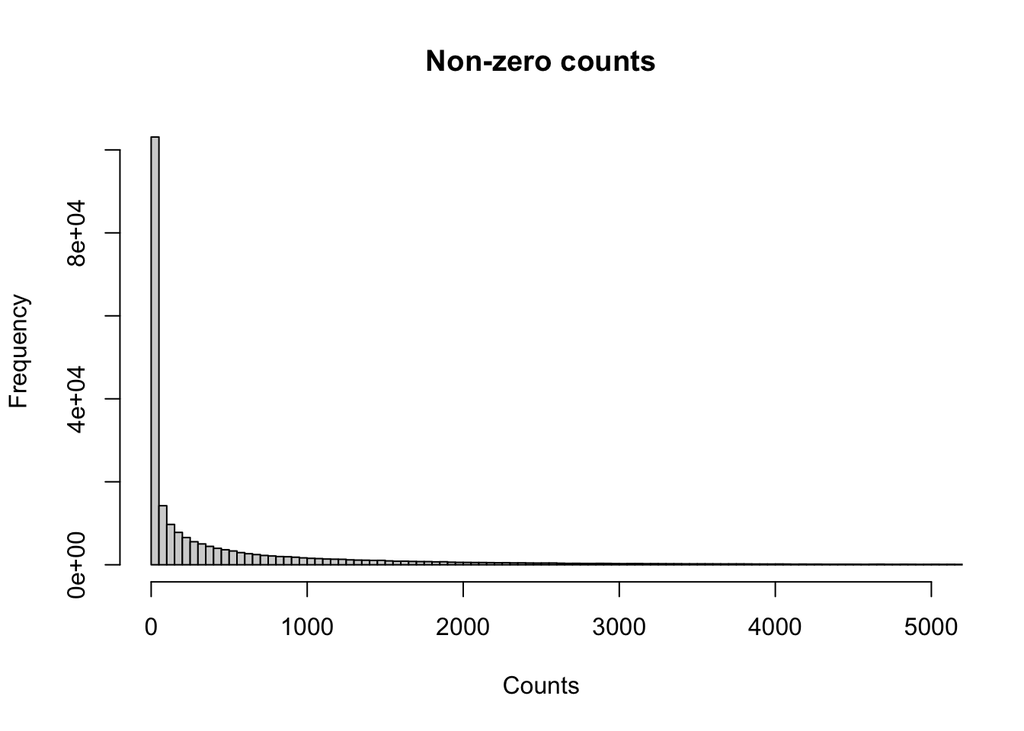

```r
## at this point, you should have lost ~20000 genes (you should have around 41000 observations). the row names should be the gene symbols, and the columns should only include the conditions of interest listed at the beginning

# next, it's good practice to inspect the data visually. make a histogram of the counts. there will be a few outliers making the graph look very weird, so play around with the scaling, number of breaks, and the limits of the x axis to see what the distribution of the bulk of the counts look like.
x <- as.matrix(counts)
x <- x[x > 0]

hist(x,
     main = "Non-zero counts",
     xlab = "Counts",
     breaks = 10000, xlim=c(0,5000))
```